# R Notebook

```r
install.packages(tidyverse)
```

```
Error in install.packages : object 'tidyverse' not found
```

```r
library(tidyverse)
```

#### Chapter 3

### Chapter 3.1

- If trying to install tidyverse and get -“there is no package called ‘tidyverse’”, need to install the run library().
- To install:  
  install.packages(“tidyverse”)  
  library(tidyverse)

### Chapter 3.2

- mpg data frame found in ggplot2 (aka ggplot2::mpg)
  - Frame is a rectangular collection of variables (in the columns) and observations (in the rows)
- To plot mpg
  - ggplot(data = mpg) + geom_point(mapping = aes(x = displ, y = hwy))
- Reusable template for making graphs with ggplot2
  - ggplot(data = ) + (mapping = aes())

## 3.2.4 Exercises

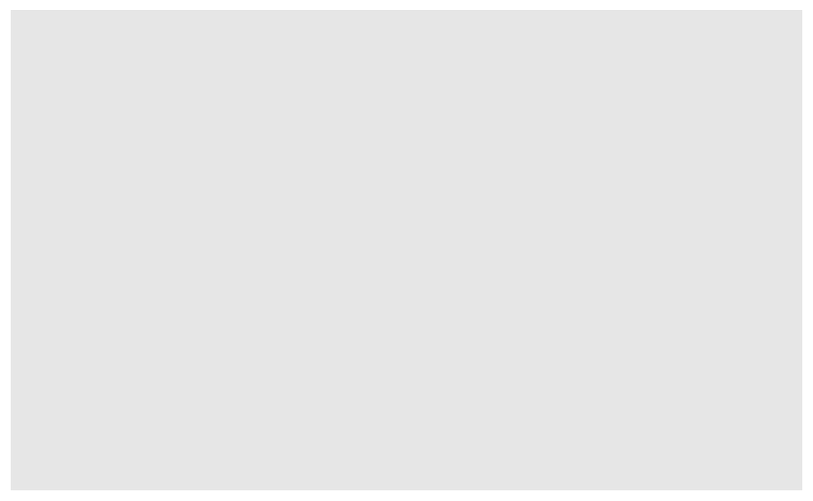

```r
ggplot(data = mpg)
```

1. It shows a blank plot graph

```r
nrow(mpg)
```

```
[1] 234
```

```r
ncol(mpg)
```

```
[1] 11
```

2. 234 rows are in mpg. 11 columns.
3. Drv variable describe f = front-wheel drive, r = rear wheel drive, 4 = 4wd.

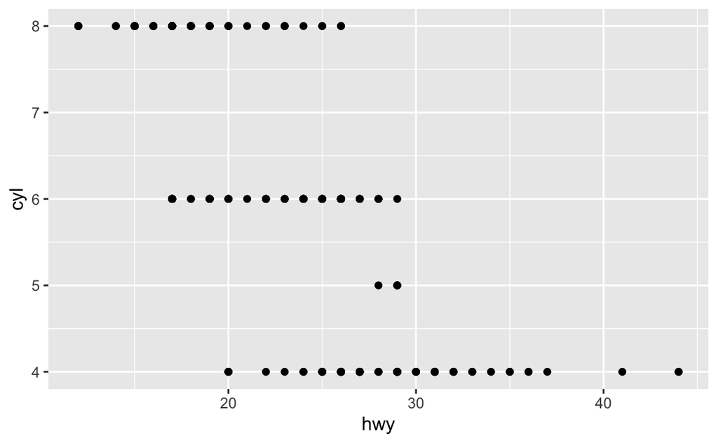

```r
ggplot(data = mpg) +
  geom_point(mapping = aes(x = hwy, y = cyl))
```

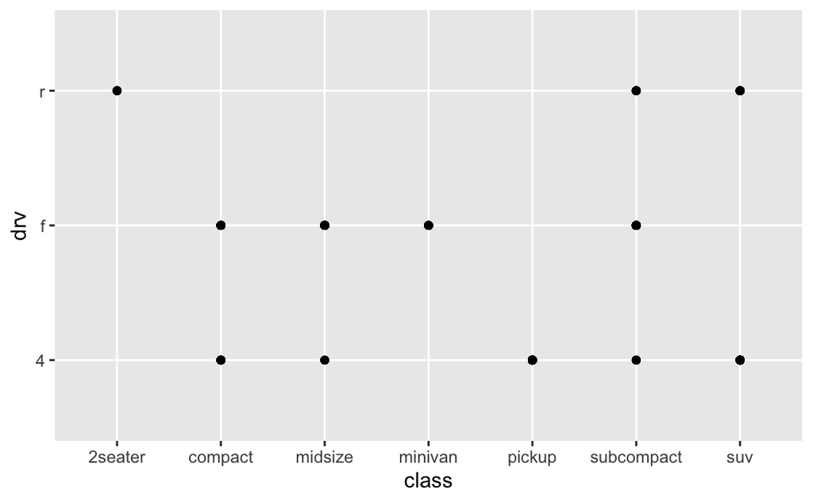

```r
ggplot(data = mpg) +
  geom_point(mapping = aes(x = class, y = drv))
```

5. The scatterplot of class vs drv show us each varable compared to drv. The plot not useful because the graph contains varbale unnessary to what we are trying to research.

### Chapter 3.3

- Aesthetic is a visual property of the objects in your plot
  - size, the shape, or the color of points
  - ggplot(data = mpg) + geom_point(mapping = aes(x = displ, y = hwy, color = class))
  - ggplot(data = mpg) +
    - All class diffent color geom_point(mapping = aes(x = displ, y = hwy, size = class))
  - ggplot(data = mpg) + geom_point(mapping = aes(x = displ, y = hwy, alpha = class))
  - ggplot(data = mpg) + geom_point(mapping = aes(x = displ, y = hwy, shape = class))
  - ggplot(data = mpg) + geom_point(mapping = aes(x = displ, y = hwy), color = “blue”)
    - All class same color

## 3.3.1 Exercises

1. The points are not blue becaues the code is wrong. The “color =”blue" is suposed to be in diffrent parentheses then the “x = displ, y = hwy” and the code included then in the same parentheses.

Categorical: model, trans, drv, fl, class

Continuous: displ, year, cty, hwy, cyl

When I run mpg it list out all the variables and what they stand for.

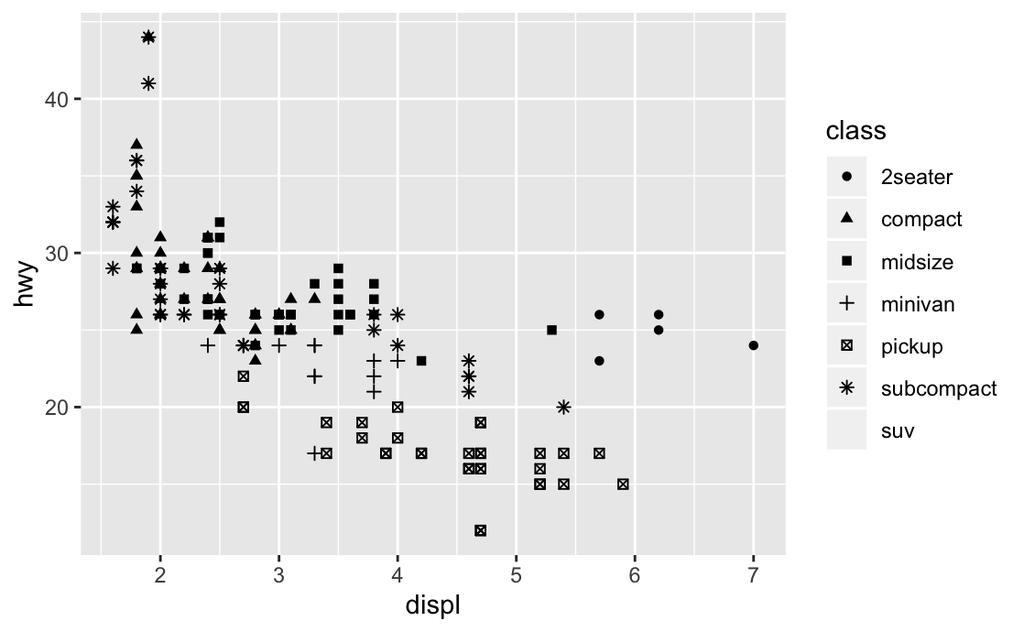

```r
ggplot(data = mpg) +
  geom_point(mapping = aes(x = displ, y = hwy, shape = class))
```

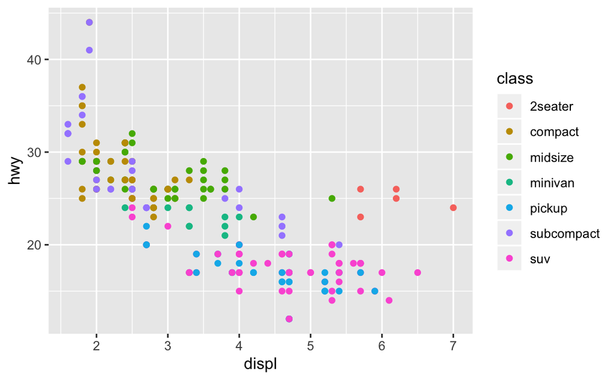

```r
ggplot(data = mpg) +
  geom_point(mapping = aes(x = displ, y = hwy, color = class))
```

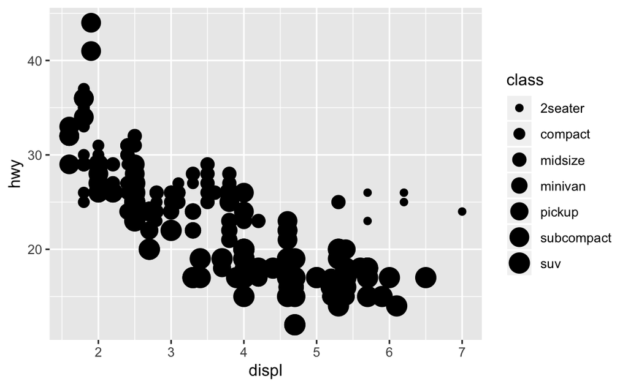

```r
ggplot(data = mpg) +
  geom_point(mapping = aes(x = displ, y = hwy, size = class))
```

The aesthetics change in size, shape, and color from categorical to continuous variables.

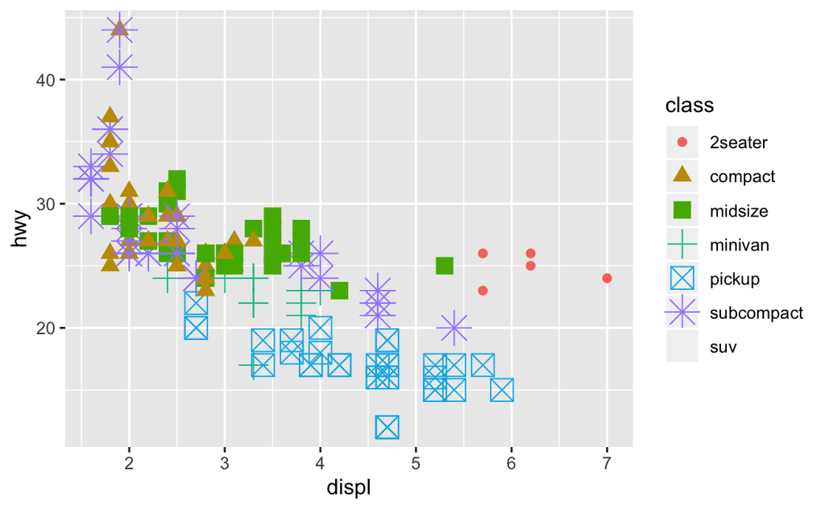

```r
ggplot(data = mpg) +
  geom_point(mapping = aes(x = displ, y = hwy, shape = class, color = class, size = class))
```

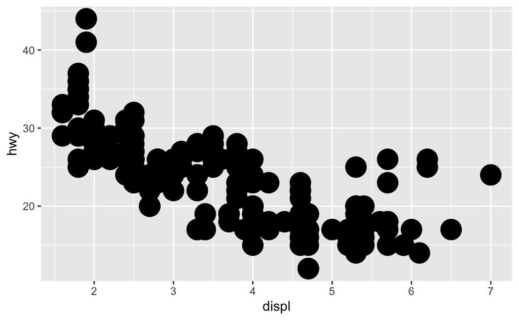

```r
ggplot(data = mpg) +
  geom_point(mapping = aes(x = displ, y = hwy, stroke = 5))
```

Stroke aesthetic changes the border of the level.

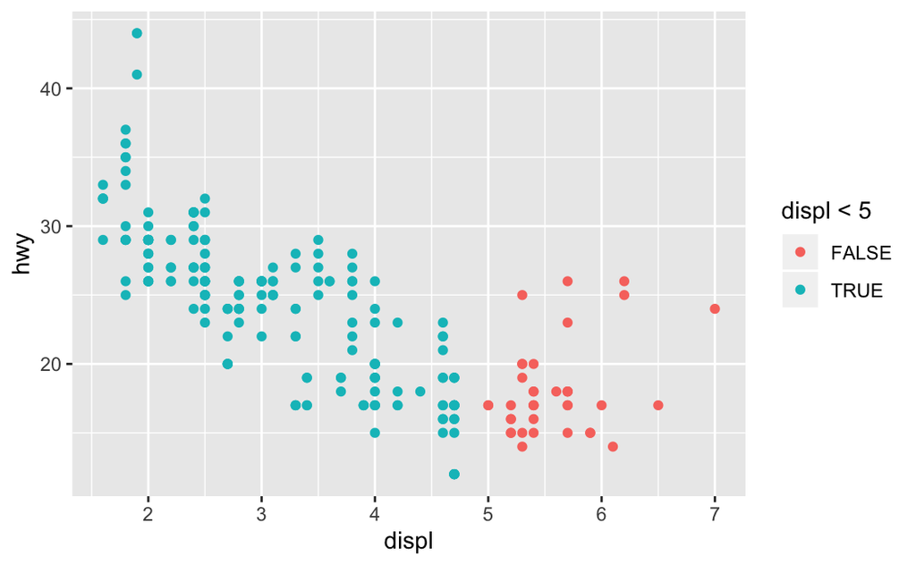

```r
ggplot(data = mpg) +
  geom_point(mapping = aes(x = displ, y = hwy, colour = displ < 5))
```

If you map an aesthetic to something other than a variable name, like aes(colour = displ < 5) the color of the levels stays blue untill it reaches the 5 mark in the x-axis then the color turnes red.

### Chapter 3.4

- ggplot(data = mpg) +geom_point(mapping = aes(x = displ, y = hwy))
  - (+) in wrong place
- can get help by running ?function_name in console

### Chapter 3.5

- Split plot into facets (subplots)
  - ggplot(data = mpg) + geom_point(mapping = aes(x = displ, y = hwy)) + facet_wrap(~ class, nrow = 2)

## 3.5.1 Exercises

1. Subplots appear to graph each variable individually but overall on one large scale

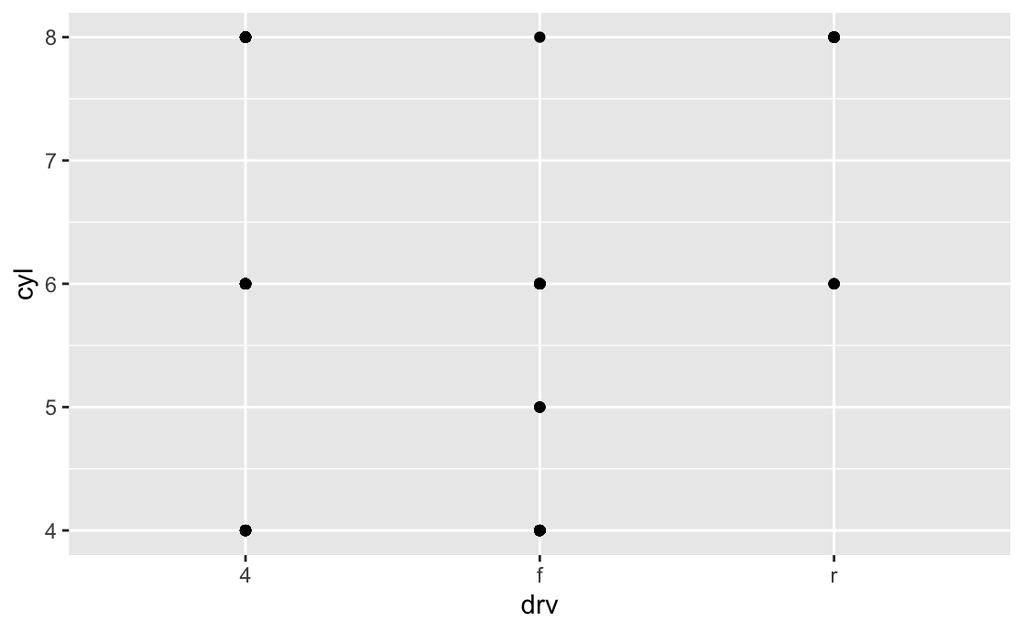

```r
ggplot(data = mpg) +
  geom_point(mapping = aes(x = drv, y = cyl))
```

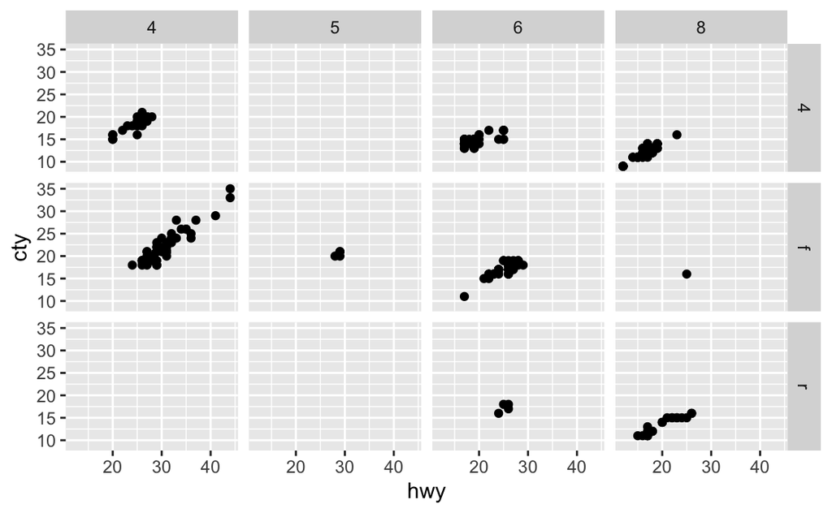

```r
ggplot(data = mpg) +
  geom_point(mapping = aes(x = hwy, y = cty)) +
  facet_grid(drv ~ cyl)
```

We are only testing for two variable, some cells are empty becaue there are not observations for those plots.

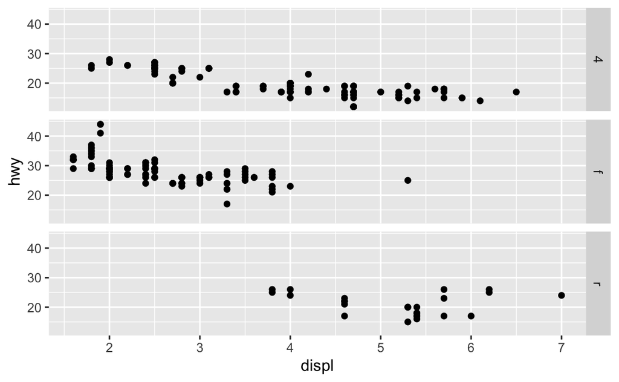

```r
ggplot(data = mpg) +
  geom_point(mapping = aes(x = displ, y = hwy)) +
  facet_grid(drv ~ .)
```

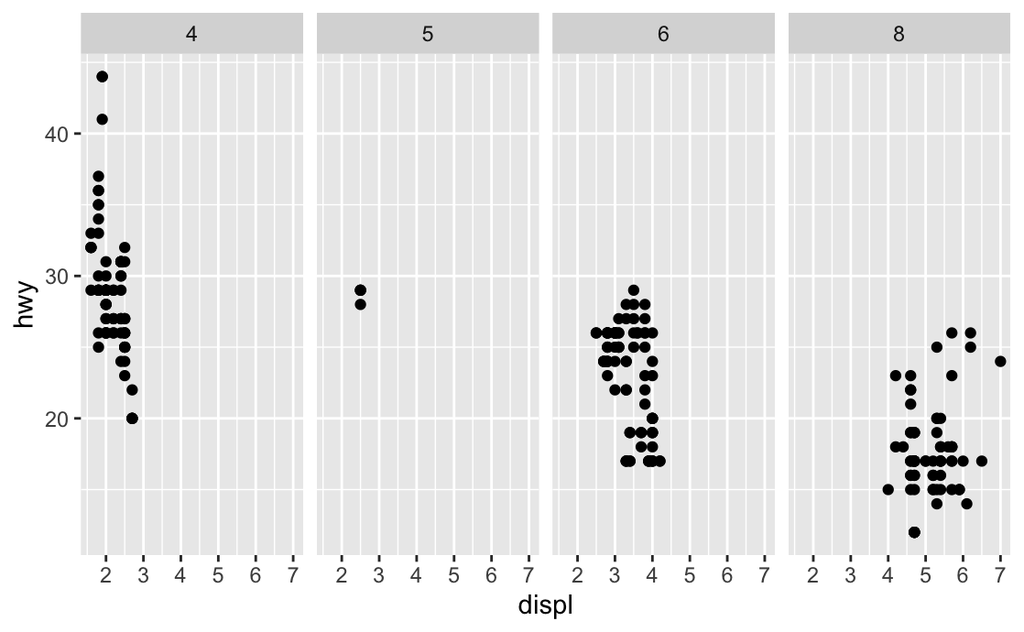

```r
ggplot(data = mpg) +
  geom_point(mapping = aes(x = displ, y = hwy)) +
  facet_grid(. ~ cyl)
```

It made 4 vertical facets, indiidual plots. The “.” in the code ignore dimensions when faceting

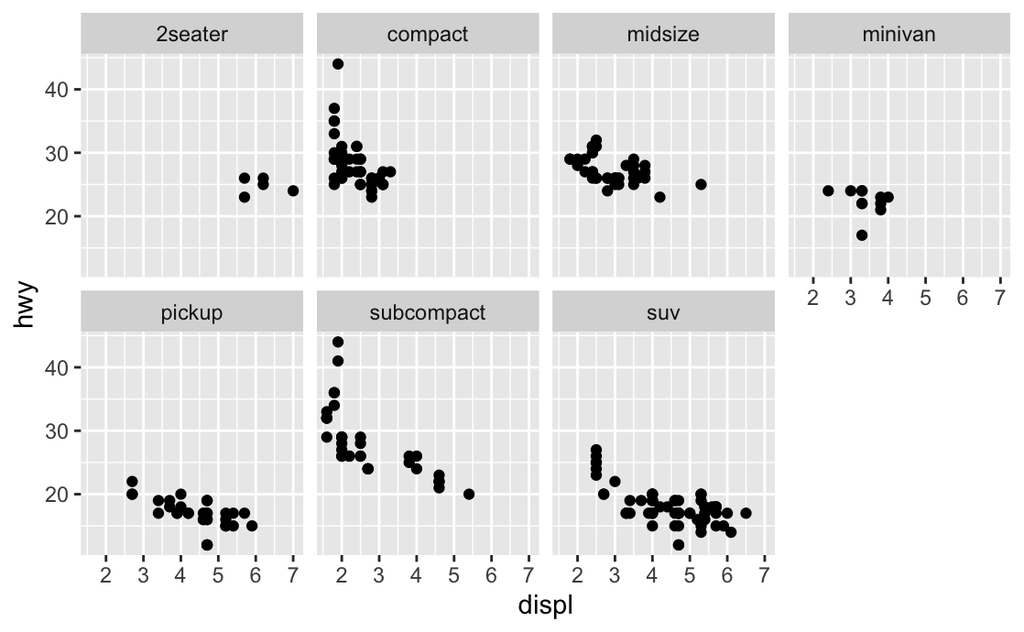

```r
ggplot(data = mpg) +
  geom_point(mapping = aes(x = displ, y = hwy)) +
  facet_wrap(~ class, nrow = 2)
```

The advantages of using faceting instead of the colour aesthetic is that we can see the variables individually clearly on a separately plot. The disadvantages are that it makes it harder to compare the variables

5. nrow shows you the numbers of row you have. ncol shows you the numbers of columns you have.Other options control the layout of the individual panels are scales, shrink, and labeller. facet_grid() don’t have nrow and ncol arguments becaues the are unique values of variable that are specified by the rows and columns.
6. When using facet_grid() you should usually put the variable with more unique levels in the columns becaues if it is layed our horizontally you can see the the value in the columns better.

### Chapter 3.6

- A geom is the geometrical object that a plot uses to represent data.
- To change the geom in your plot, change the geom function that you add to ggplot()
  - ggplot(data = mpg) + geom_point(mapping = aes(x = displ, y = hwy))
  - ggplot(data = mpg) + geom_smooth(mapping = aes(x = displ, y = hwy))
- geom_smooth() will draw a different line, with a different linetype, for each unique value of the variable that you map to linetype.
  - ggplot(data = mpg) + geom_smooth(mapping = aes(x = displ, y = hwy, linetype = drv))
  - geom_smooth() separates the cars into three lines based on their drv value
- learn more about any single geom, use help: ?geom_smooth.
- the group aesthetic by itself does not add a legend or distinguishing features to the geoms.
  - ggplot(data = mpg) + geom_smooth(mapping = aes(x = displ, y = hwy))
  - ggplot(data = mpg) + geom_smooth(mapping = aes(x = displ, y = hwy, group = drv))
  - ggplot(data = mpg) + geom_smooth(mapping = aes(x = displ, y = hwy, color = drv), show.legend = FALSE
- To display multiple geoms in the same plot, add multiple geom functions to ggplot(): -ggplot(data = mpg) + geom_point(mapping = aes(x = displ, y = hwy)) + geom_smooth(mapping = aes(x = displ, y = hwy)) -This makes it possible to display different aesthetics in different layers.
  - ggplot(data = mpg, mapping = aes(x = displ, y = hwy)) + geom_point(mapping = aes(color = class)) + geom_smooth()

## 3.6.1 Exercises

1. What geom would you use to draw a line chart? A boxplot? A histogram? An area chart?

geom_line chart()  
geom_boxplot()  
geom_histogram()  
geom_area chart()

2. I predict the graph will have miltiple colors and lines in it as well as plot points.

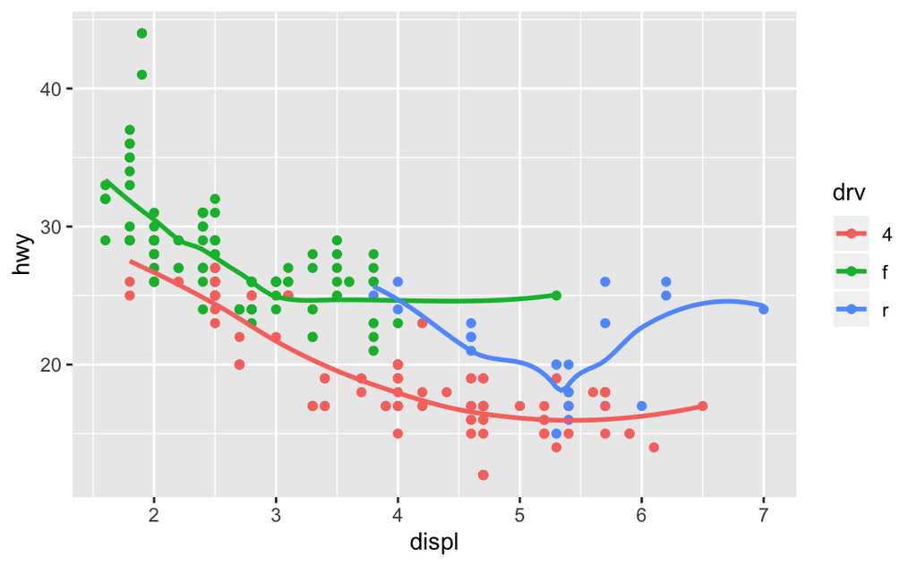

```r
ggplot(data = mpg, mapping = aes(x = displ, y = hwy, color = drv)) +
  geom_point() +
  geom_smooth(se = FALSE)
```

3. show.legend = FALSE will hide the legand. If you remove it you will see the legand. I think you used it earlier in the chapter to hide the legend and make the document look nicer.
4. The argument geom_smooth() helps your eyes into seeing the patterns in the graph when there is overplotting.
5. The two graphs will look the same because they used the code that produces the same plot as the previous code.
6. Recreate the R code necessary to generate the following graphs.

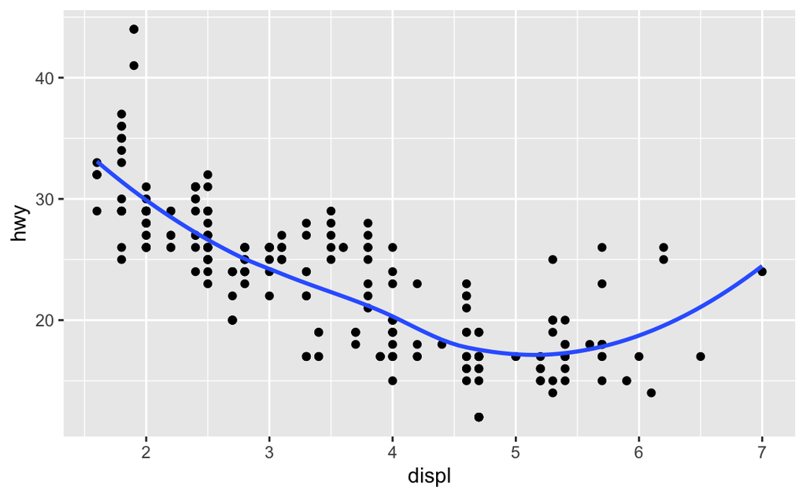

```r
ggplot(mpg, aes(x = displ, y = hwy)) +
  geom_point() +
  geom_smooth(se = FALSE)
```

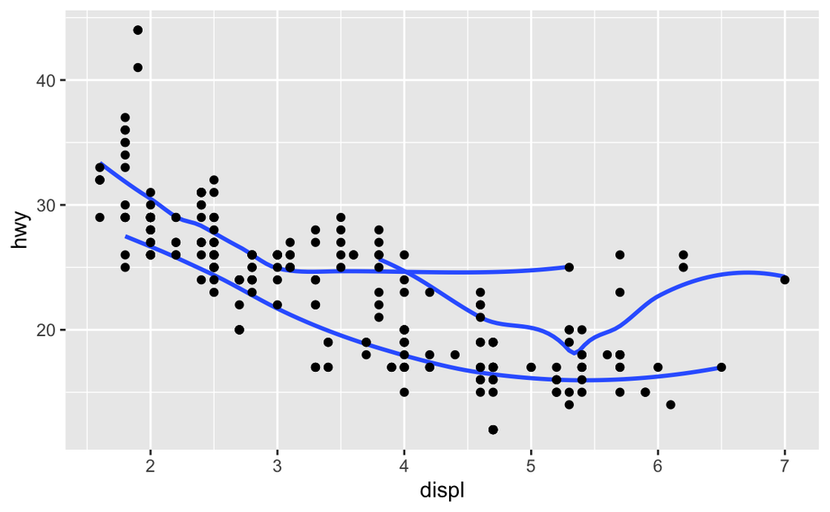

```r
ggplot(mpg, aes(x = displ, y = hwy)) +
  geom_smooth(mapping = aes(group = drv), se = FALSE) +
  geom_point()
```

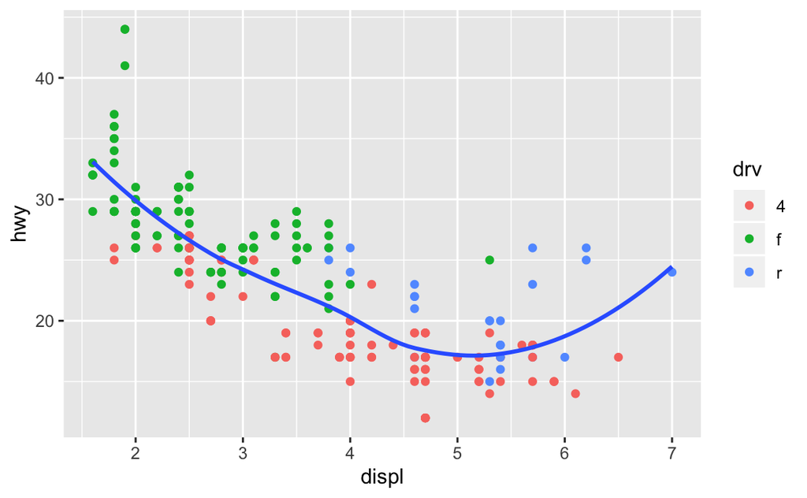

```r
ggplot(mpg, aes(x = displ, y = hwy)) +
  geom_point(aes(colour = drv)) +
  geom_smooth(se = FALSE)
```

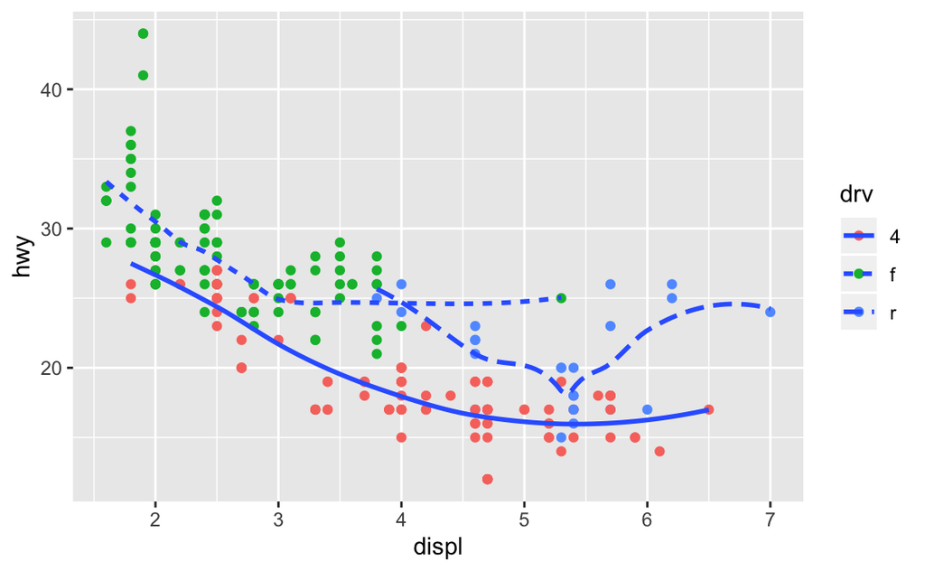

```r
ggplot(mpg, aes(x = displ, y = hwy)) +
  geom_point(aes(colour = drv)) +
  geom_smooth(aes(linetype = drv), se = FALSE)
```

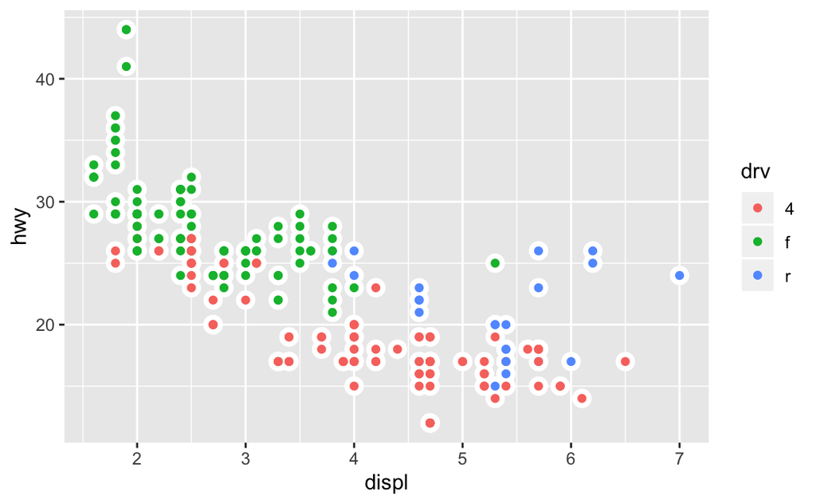

```r
ggplot(mpg, aes(x = displ, y = hwy)) +
  geom_point(size = 4, colour = "white") +
  geom_point(aes(colour = drv))
```

### Chapter 3.7

- Learn which stat a geom uses by doing ?geom_bar
  - Shows that the default value for stat is “count”, which means that geom_bar() uses stat_count(). stat_count()
  - ggplot(data = diamonds) + stat_count(mapping = aes(x = cut)) -Each column havd diffrent lables
- Override defalt
  - Change the stat of geom_bar() from count (the default) to identity
- where the height of the bar is generated by counting rows
  - ggplot(data = demo) + geom_bar(mapping = aes(x = cut, y = freq), stat = “identity”)
- stat_summary(), which summarises the y values for each unique x value, to draw attention to the summary that you’re computing
  - ggplot(data = diamonds) + stat_summary( mapping = aes(x = cut, y = depth), fun.ymin = min, fun.ymax = max, fun.y = median)

## 3.7.1 Exercises

1. The default geom associated with stat_summary() uses mean ans sd to gwt the middle point and end point of a line.

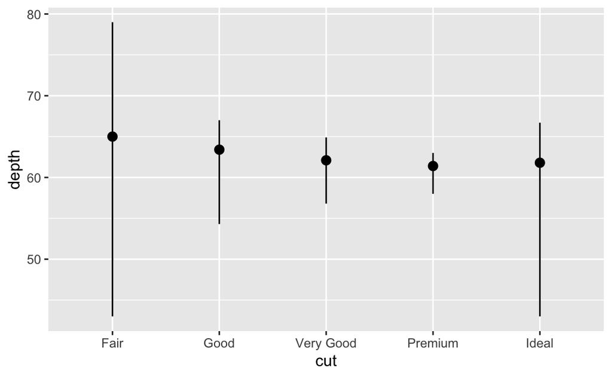

```r
ggplot(data = diamonds) +
  geom_pointrange(
    mapping = aes(x = cut, y = depth),
    stat = "summary",
    fun.ymin = min,
    fun.ymax = max,
    fun.y = median
  )
```

2. geom_col() and geom_bar() are types of bar charts. geom_bar() makes the height of the bar proportional to the number of cases in each group.
3. width, binwidth: Change the resolution of the data.  
   geom, stat: Override the default connection between geom_bar() and stat_count().
4. stat_smooth() compute the variables:  
   y: predicted value  
   ymin: lower value of the confidence interval  
   ymax: upper value of the confidence interval  
   se: standard error

Parameters thar control its behaviour: - formula - na.rm -methods

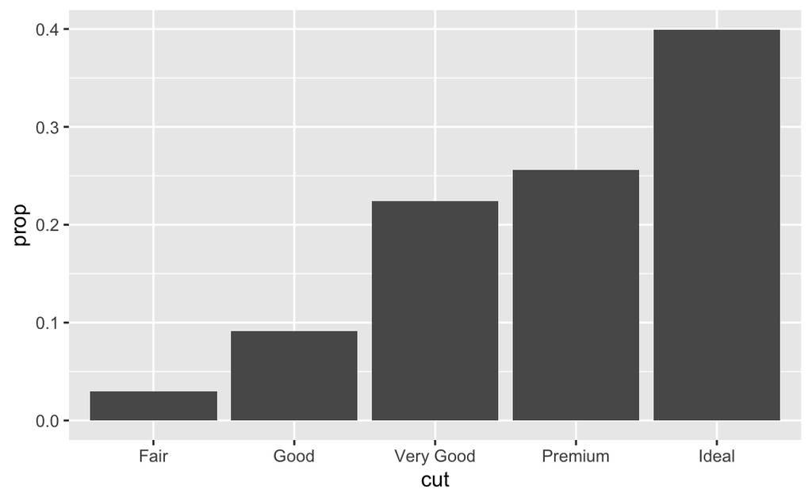

```r
ggplot(data = diamonds) +
  geom_bar(mapping = aes(x = cut, y = ..prop.., group = 1))
```

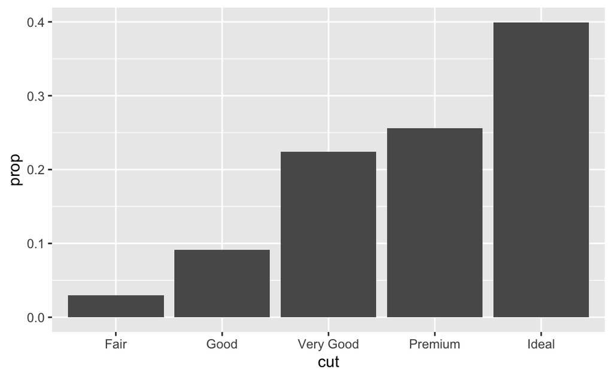

```r
ggplot(data = diamonds) +
  geom_bar(mapping = aes(x = cut, fill = color, y = ..prop.., group = 1))
```

By setting group = 1, you can visualy see the diffrence of quility of the diamonds in the graph.